## Top Weather Events Affecting Population and Economy Between 1989 and 2011

### Synopsis

The purpose of this analysis is to determine the weather events that had the greatest impact on population health and the economy between 1989 and 2011. The analysis leverages data from the NOAA Storm Database which tracks severe weather events in the Unites States. The events in the database start in January 1950 and end in November 2011. However, due to the small number of events recorded in earlier years, only data from 1989 to 2011 are used in the analysis. From these data, we discover that the top 3 weather events affecting population health are Tornado, Storm and Heat, accounting for 66% of fatalities and injuries in the United States between 1989 and 2011. During the same timeframe, the top 3 weather events that resulted in the greatest economic consequences are Flood, Storm and Tornado, accounting for 82% of property and crop damage.

### Data Processing

From the [NOAA Storm Database](https://d396qusza40orc.cloudfront.net/repdata%2Fdata%2FStormData.csv.bz2), we obtain data on weather events occurring in the United States. The data come in the form of a comma-separated-value file compressed via the bzip2 algorithm. We uncompress this file and load all of its contents in to R.

```r
storm <- read.table(bzfile("repdata-data-StormData.csv.bz2"),
                    sep=",", header=TRUE, stringsAsFactors=FALSE)
```

We explore the data structure as well as the first few observations to gain an understanding of the data.

```r
str(storm)
```

```
## 'data.frame':    902297 obs. of  37 variables:
##  $ STATE__   : num  1 1 1 1 1 1 1 1 1 1 ...
##  $ BGN_DATE  : chr  "4/18/1950 0:00:00" "4/18/1950 0:00:00" "2/20/1951 0:00:00" "6/8/1951 0:00:00" ...
##  $ BGN_TIME  : chr  "0130" "0145" "1600" "0900" ...
##  $ TIME_ZONE : chr  "CST" "CST" "CST" "CST" ...
##  $ COUNTY    : num  97 3 57 89 43 77 9 123 125 57 ...
##  $ COUNTYNAME: chr  "MOBILE" "BALDWIN" "FAYETTE" "MADISON" ...
##  $ STATE     : chr  "AL" "AL" "AL" "AL" ...
##  $ EVTYPE    : chr  "TORNADO" "TORNADO" "TORNADO" "TORNADO" ...
##  $ BGN_RANGE : num  0 0 0 0 0 0 0 0 0 0 ...
##  $ BGN_AZI   : chr  "" "" "" "" ...
##  $ BGN_LOCATI: chr  "" "" "" "" ...
##  $ END_DATE  : chr  "" "" "" "" ...
##  $ END_TIME  : chr  "" "" "" "" ...
##  $ COUNTY_END: num  0 0 0 0 0 0 0 0 0 0 ...
```

[output cut: 23 more lines]

```r
head(storm)
```

```
##   STATE__           BGN_DATE BGN_TIME TIME_ZONE COUNTY COUNTYNAME STATE
## 1       1  4/18/1950 0:00:00     0130       CST     97     MOBILE    AL
## 2       1  4/18/1950 0:00:00     0145       CST      3    BALDWIN    AL
## 3       1  2/20/1951 0:00:00     1600       CST     57    FAYETTE    AL
## 4       1   6/8/1951 0:00:00     0900       CST     89    MADISON    AL
## 5       1 11/15/1951 0:00:00     1500       CST     43    CULLMAN    AL
## 6       1 11/15/1951 0:00:00     2000       CST     77 LAUDERDALE    AL
##    EVTYPE BGN_RANGE BGN_AZI BGN_LOCATI END_DATE END_TIME COUNTY_END
## 1 TORNADO         0                                               0
## 2 TORNADO         0                                               0
## 3 TORNADO         0                                               0
## 4 TORNADO         0                                               0
## 5 TORNADO         0                                               0
## 6 TORNADO         0                                               0
##   COUNTYENDN END_RANGE END_AZI END_LOCATI LENGTH WIDTH F MAG FATALITIES
```

[output cut: 20 more lines]

```r
orig_n <- nrow(storm)
orig_n
```

```
## [1] 902297
```

In order to determine how much of the data we will use for the analysis, we convert “BGN_DATE” from character to a date datatype and look at the number of weather events entered by year. We then examine what percentage of the total events from 1950 to 2011 each year accounts for.

```r
storm$EVDATE <- as.Date(storm$BGN_DATE, "%m/%d/%Y")
ev_by_yr     <- aggregate(EVTYPE~format(EVDATE, "%Y"), data=storm, length)
ev_by_yr$PCT <- ev_by_yr$EVTYPE/sum(ev_by_yr$EVTYPE)*100
ev_by_yr
```

```
##    format(EVDATE, "%Y") EVTYPE        PCT
## 1                  1950    223 0.02471470
## 2                  1951    269 0.02981280
## 3                  1952    272 0.03014528
## 4                  1953    492 0.05452750
## 5                  1954    609 0.06749441
## 6                  1955   1413 0.15660032
## 7                  1956   1703 0.18874051
## 8                  1957   2184 0.24204890
## 9                  1958   2213 0.24526292
## 10                 1959   1813 0.20093162
## 11                 1960   1945 0.21556095
## 12                 1961   2246 0.24892026
## 13                 1962   2389 0.26476870
## 14                 1963   1968 0.21811000
```

[output cut: 48 more lines]

From the output, we see that years 1950 to 1988 each account for less than 1% of the total events in the database. For this analysis, we will only use data for those years which account for at least 1% of the total events in the database. In this case, these are years 1989 to 2011.

```r
storm2 <- subset(storm, format(EVDATE, "%Y") > "1988" )
n1 <- nrow(storm2)
n1
```

```
## [1] 762150
```

We see that we have reduced the number of observations from 902297 to 762150.

Next we explore the EVTYPE variable and discover that there are 985 different event types recorded in the database. For the sake of saving space on this report, we show only the first 20 event types.

```r
# number of unique events
length(unique(storm2$EVTYPE))
```

```
## [1] 985
```

```r
# display top 20 events
head(unique(storm2$EVTYPE),20)
```

```
##  [1] "TORNADO"                   "TSTM WIND"
##  [3] "HAIL"                      "FREEZING RAIN"
##  [5] "SNOW"                      "ICE STORM/FLASH FLOOD"
##  [7] "SNOW/ICE"                  "WINTER STORM"
##  [9] "HURRICANE OPAL/HIGH WINDS" "THUNDERSTORM WINDS"
## [11] "RECORD COLD"               "HURRICANE ERIN"
## [13] "HURRICANE OPAL"            "HEAVY RAIN"
## [15] "LIGHTNING"                 "THUNDERSTORM WIND"
## [17] "DENSE FOG"                 "RIP CURRENT"
## [19] "THUNDERSTORM WINS"         "FLASH FLOOD"
```

As can be seen, the 985 EVTYPEs are not unique event types. For example, hurricane can appear as HURRICANE OPAL/HIGH WINDS, HURRICANE ERIN and HURRICANE OPAL. Due to this, we have decided to group event types into 14 categories.

```r
storm2$EVCAT <- ifelse(grepl("TORN|SPOUT|WALL", storm2$EVTYPE, ignore.case=TRUE), "TORNADO",
               ifelse(grepl("THU|TSTM|TUN|FUNNEL|STORM|TROP|TSUN|TYPH|COASTAL", storm2$EVTYPE, ignore.case=TRUE),"STORM",
               ifelse(grepl("HURR", storm2$EVTYPE, ignore.case=TRUE), "HURRICANE",
               ifelse(grepl("FIRE|SMOKE", storm2$EVTYPE, ignore.case=TRUE), "WILDFIRE",
               ifelse(grepl("CURR|TIDE|SURF|ROGUE|RISING|WAVES", storm2$EVTYPE, ignore.case=TRUE), "TIDES",
               ifelse(grepl("LIGHTNING|LIGN|LIGHTING", storm2$EVTYPE, ignore.case=TRUE), "LIGHTNING",
               ifelse(grepl("HEAT|WARM|DROUGHT|HIGH TEMP|RECORD HIGH|HOT|DRIEST", storm2$EVTYPE, ignore.case=TRUE), "HEAT",
               ifelse(grepl("COLD|FREEZ|CHILL|FROST|WINT|ICE|ICY|SNOW|SLEET|BLIZZ|GLAZE|LOW TEMP|RECORD LOW|DRY",
                            storm2$EVTYPE, ignore.case=TRUE), "COLD",
               ifelse(grepl("FLOOD|HIGH WATER|FLD|LAND|MUD|FLOOOD|FLOYD", storm2$EVTYPE, ignore.case=TRUE), "FLOOD",
               ifelse(grepl("HAIL", storm2$EVTYPE, ignore.case=TRUE), "HAIL",
               ifelse(grepl("RAIN|PRECIP|SHOWER|WET", storm2$EVTYPE, ignore.case=TRUE), "RAIN",
               ifelse(grepl("WIND|BURST|WND", storm2$EVTYPE, ignore.case=TRUE), "WIND",
               ifelse(grepl("DUST", storm2$EVTYPE, ignore.case=TRUE), "DUST", "OTHER")))))))))))))

table(storm2$EVCAT)
```

```
##
##      COLD      DUST     FLOOD      HAIL      HEAT HURRICANE LIGHTNING
##     33788       158     85906    245337      5501       200     15767
##     OTHER      RAIN     STORM     TIDES   TORNADO  WILDFIRE      WIND
##      2575     11994    293646      2129     34597      4261     26291
```

As can be seen above, the rules ensure that multiple EVTYPEs that represent the same event are grouped in the same category. The categories themselves are chosen after examining the data and are believed to be a good representation of the different classes of weather events. It must be noted that the category “OTHER” includes all other event types that do not fall under the 13 categories created. No further cleansing is applied to this category as the total number of records is relatively small.

To determine the impact of events on population health and economy, we look at the following variables: FATALITIES, INJURIES, PROPDMG and CROPDMG. Since only the events that had an impact on any of these factors are of interest to us, we subset the data to only include records with non-zero values in at least one of these variables.

```r
s <- subset(storm2, FATALITIES>0 | INJURIES>0 | PROPDMG>0 | CROPDMG>0)
n2 <- nrow(s)
n2
```

```
## [1] 230903
```

We see that we have reduced the number of observations from 762150 to 230903.

Examining the data, we see two other fields that are related PROPDMG and CROPDMG, namely, PROPDMGEXP and CROPDMGEXP.

```r
unique(s$PROPDMGEXP)
```

```
##  [1] "M" "K" ""  "B" "m" "+" "0" "5" "6" "4" "h" "2" "7" "3" "H" "-"
```

```r
unique(s$CROPDMGEXP)
```

```
## [1] ""  "M" "K" "m" "B" "?" "0" "k"
```

Due to the absence of a code book for the storm data, we need to make assumptions on the meaning of these two variables. Here we assume that PROPDMG and CROPDMG represent dollar amounts, and PROPDMGEXP and CROPDMGEXP represent the multipliers for these dollar amounts. From the output above, we make the following assumptions:

- H/h = hundred
- K/k = thousand
- M/m = million
- B = billion

We now look at how to handle the other values of PROPDMGEXP and CROPDMGEXP.

```r
numrecs <- nrow(subset(s, !(s$PROPDMGEXP %in% c("H","h","K","k","M","m","B")) &
                          !(s$CROPDMGEXP %in% c("H","h","K","k","M","m","B"))))
numrecs
```

```
## [1] 6873
```

```r
pct_affected <- paste(format(numrecs/nrow(s)*100, digits=3),"%",sep="")
pct_affected
```

```
## [1] "2.98%"
```

From above, we see that only 6873 observations have multiplier values that are not part of the values in our assumption. As this only affects 2.98% of our data, we make the decision to interpret these multiplier values as 0.

With these assumptions, we create new fields representing PROPDMG and CROPDMG amounts. In addition, we create a new field representing total FATALITIES and INJURIES.

```r
s$PROPDMGAMT <- ifelse(s$PROPDMGEXP %in% c("H","h"), s$PROPDMG*100,
                ifelse(s$PROPDMGEXP %in% c("K","k"), s$PROPDMG*1000,
                ifelse(s$PROPDMGEXP %in% c("M","m"), s$PROPDMG*1000000,
                ifelse(s$PROPDMGEXP=="B", s$PROPDMG*1000000000,0))))

s$CROPDMGAMT <- ifelse(s$CROPDMGEXP %in% c("H","h"), s$CROPDMG*100,
                ifelse(s$CROPDMGEXP %in% c("K","k"), s$CROPDMG*1000,
                ifelse(s$CROPDMGEXP %in% c("M","m"), s$CROPDMG*1000000,
                ifelse(s$CROPDMGEXP=="B", s$CROPDMG*1000000000,0))))

s$TOTALDMGAMT <- s$PROPDMGAMT + s$CROPDMGAMT

s$TOTALDMGPOP <- s$FATALITIES + s$INJURIES
```

### Results

#### Across the United States, which types of events are most harmful with respect to population health?

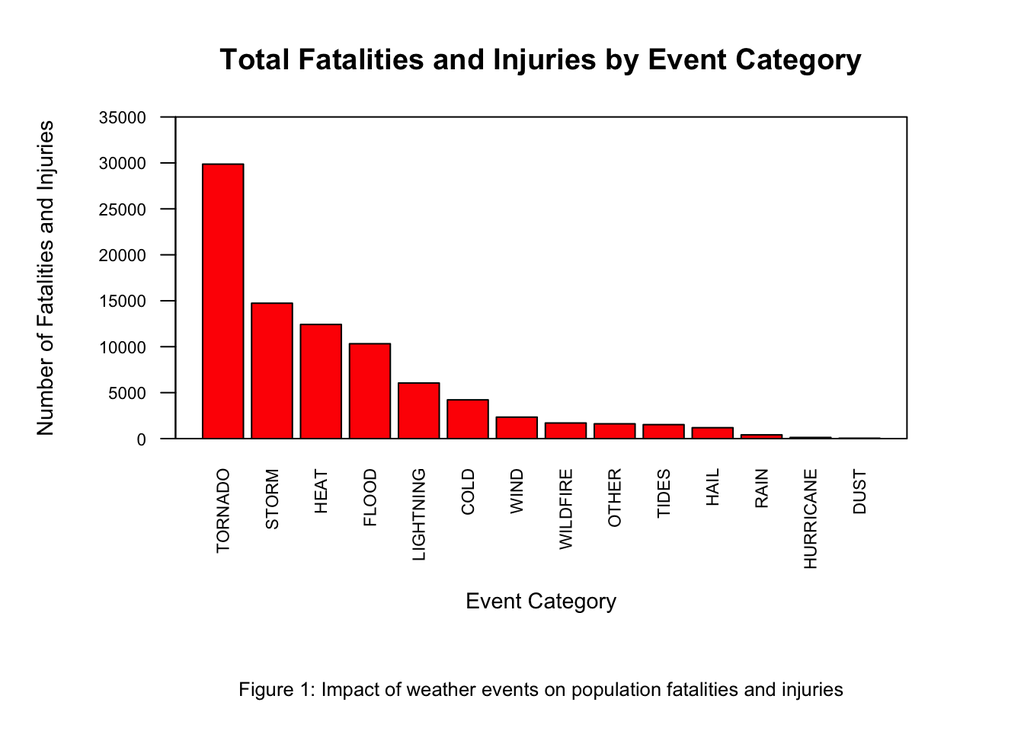

```r
# compute total number of fatalities and injuries for each event category
p <- aggregate(TOTALDMGPOP~EVCAT, data=s, sum)
p$PCTDMGPOP <- p$TOTALDMGPOP/sum(p$TOTALDMGPOP) * 100
p2 <- p[order(-p$TOTALDMGPOP),]

# plot results
par(mar=c(10,6,4,4))
barplot(p2$TOTALDMGPOP, names = p2$EVCAT,
      main="Total Fatalities and Injuries by Event Category",
      ylim=c(0,35000), col='red',las=2, cex.names=0.7, cex.axis=0.7, cex.lab=1)
mtext(side = 1, text = "Event Category", line = 5, cex=0.9)
mtext(side = 2, text = "Number of Fatalities and Injuries", line = 4, cex=0.9)
mtext(side = 1, text = "Figure 1: Impact of weather events on population fatalities and injuries", line = 8, cex=0.8)
box()
```

This plot shows that the most harmful event to population health is Tornado, accounting for 34.5% (29,867) of fatalities and injuries in the United States between 1989 and 2011. This is followed by Storm and Heat, accounting for 17.0% (14,733) and 14.4% (12,420) of fatalities and injuries in this timeframe, respectively.

#### Across the United States, which types of events have the greatest economic consequences?

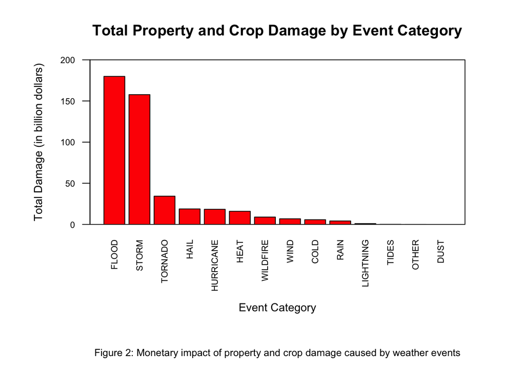

```r
# compute total damage amount by event category
e <- aggregate(TOTALDMGAMT~EVCAT, data=s, sum)
e$PCT <- e$TOTALDMGAMT/sum(e$TOTALDMGAMT) * 100
e2 <- e[order(-e$TOTALDMGAMT),]

# plot results
par(mar=c(10,6,4,4))
barplot(e2$TOTALDMGAMT/1000000000, names = e2$EVCAT,
      main="Total Property and Crop Damage by Event Category",
      ylim=c(0,200), col='red',las=2, cex.names=0.7, cex.axis=0.7, cex.lab=1)
mtext(side = 1, text = "Event Category", line = 5, cex=0.9)
mtext(side = 2, text = "Total Damage (in billion dollars)", line = 3, cex=0.9)
mtext(side = 1, text = "Figure 2: Monetary impact of property and crop damage caused by weather events", line = 8, cex=0.8)
box()
```

The plot shows that the most harmful event in terms of economic consequences is Flood, accounting for 39.8% ($180B) of property and crop damage in the United States between 1989 and 2011. This is followed by Storm and Tornado, accounting for 34.9% ($158B) and 7.6% ($34B) of damages in this timeframe, respectively.